# Análise Exploratória dos municípios que adotaram política de isenção de tarifa no transporte público

ìndice de Gini dos municípios referente a 2010 - O Índice de Gini mede o grau de concentração de renda em determinado grupo e varia de 0 a 1, sendo 0 uma situação de completa igualdade, e 1 uma situação de completa desigualdade. A média geral do índice de Gini nos municípios estudados é de 0.48, enquanto dos municípios sem FFTP é 0.49. Há apenas uma pequena diferença nas médias. No entanto, no gráfico de densidade abaixo é possível observar que há algumas diferenças na distribuição dos valores, a curva referente às cidades com FFTP está mais à esquerda enquanto a dos outros municípios está mais à direita.

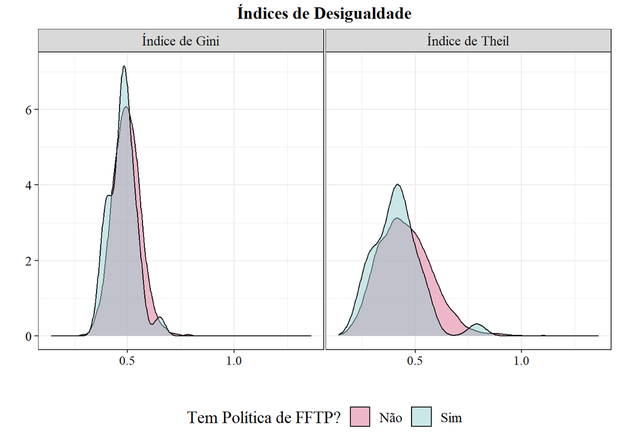

**8. Porcentagem de Pobres**

O gráfico abaixo mostra a porcentagem de pobres em cada município estudado e linha vertical representa a média nacional

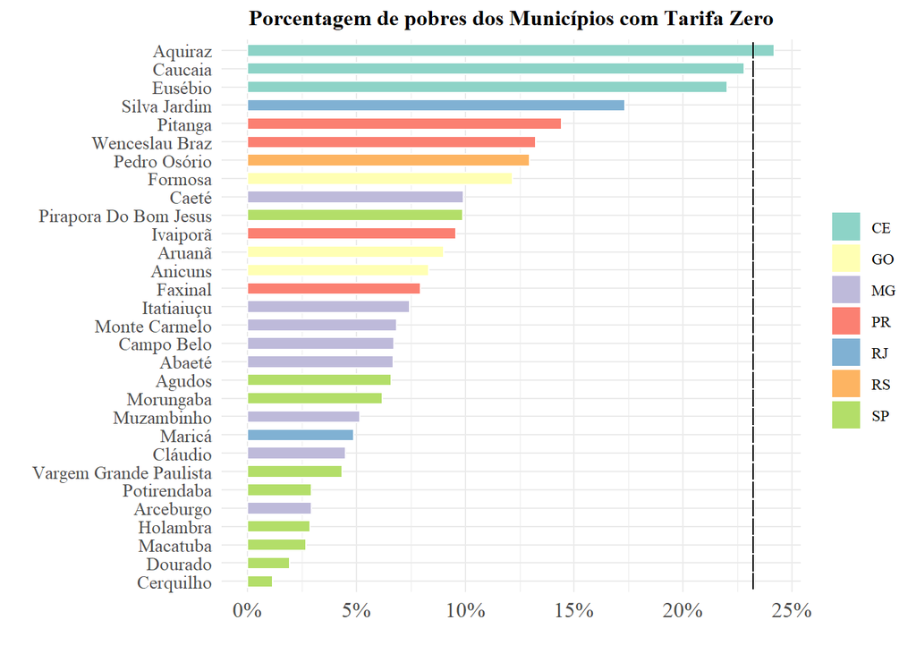

Esse indicador considera pobre o indivíduo que recebe menos que 436 reais como renda mensal, que é a linha de pobreza recomendada internacionalmente para uso em países de renda média-alta com é o caso do Brasil. Há uma diferença considerável entre as médias encontradas no grupo de cidades que adotaram FFTP e os que não adotaram. Enquanto o primeiro grupo tem uma média de porcentagem de pobres de 8.92%, o segundo grupo tem 23.28%, o que corresponde a uma diferença de 14%. Observando o gráfico de densidade abaixo, também é possível verificar o quanto esse percentual varia nos municípios brasileiros e também o quanto a curva das cidades que adotaram FFTP está mais à esquerda do gráfico.

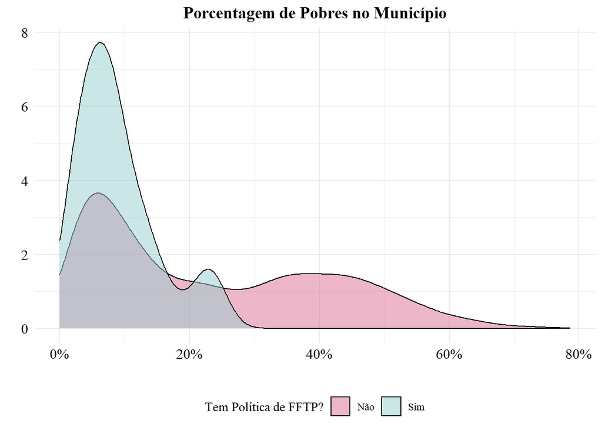

**9. Deslocamento e Pobreza**

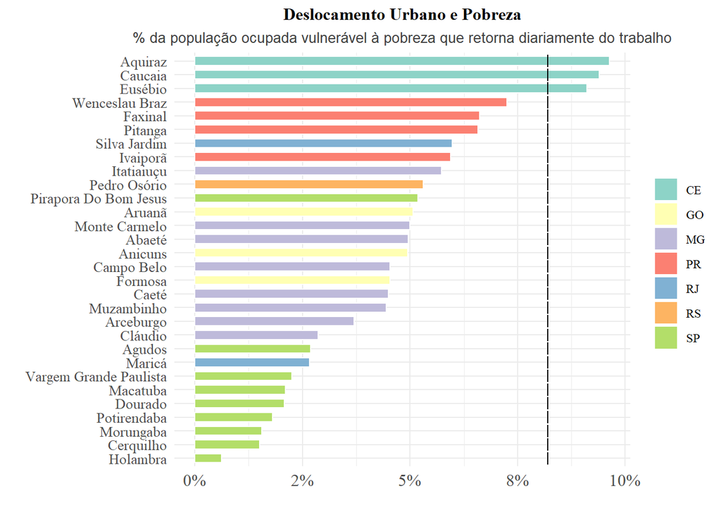